# Lab 8: Learning from Images

### Part 1: Butterfly Classification

Train, Test data set for 10 butterfly species. All images are 224 X 224 X 3 in jpg format.

```python
# Mounting Google Drive
from google.colab import drive
drive.mount('/content/drive')
```

```python
# Import libraries
import pandas as pd
from sklearn.model_selection import train_test_split
from matplotlib import pyplot as plt
from sklearn.metrics import confusion_matrix, ConfusionMatrixDisplay
from sklearn.metrics import classification_report
import numpy as np

from sklearn import preprocessing
from sklearn.metrics import confusion_matrix
from sklearn.preprocessing import StandardScaler
from itertools import chain
import torch
import torch.nn as nn
import torch.optim as optim
from torchvision import datasets, transforms
from torchvision.datasets import ImageFolder
```

```python
# Define the image preprocessing pipeline
Butterfly_trans = transforms.Compose([        # composes several transforms together
    transforms.Resize((224, 224)),
    transforms.ToTensor() # ToTensor() converts images to a torch.FloatTensor of shape (C x H x W) in the range [0.0, 1.0]
])
```

```python
# Loading images and pass the images through our preprocessing pipeline
train_butterfly10 = ImageFolder('/content/drive/MyDrive/IS675_data/Week8_data/butterfly_train_top10', transform=Butterfly_trans)
test_butterfly10 = ImageFolder('/content/drive/MyDrive/IS675_data/Week8_data/butterfly_test_top10', transform=Butterfly_trans)
```

```python
# Examine the number of classes
len(train_butterfly10.classes)
```

```
10
```

```python
# Examine the sizes of training and test data
print(len(train_butterfly10), len(test_butterfly10))
```

```
1056 50
```

[figure not shown]

```python
# Display a sample of data from test set
class_names = ['AN 88','BLUE MORPHO','COMMON WOOD-NYMPH','MONARCH','PEACOCK','PIPEVINE SWALLOW','ULYSES','VICEROY','YELLOW SWALLOW TAIL','ZEBRA LONG WING']

fig = plt.figure(figsize=(15,5))
num_classes = 10
for i in range(num_classes):
    ax = fig.add_subplot(2, 5, 1 + i, xticks=[], yticks=[])
    ax.set_title(class_names[i])
    img = next(img for img, label in test_butterfly10 if label == i)
    plt.imshow(img.permute(1, 2, 0))
plt.show()
```

```python
# Examine the tensor of a zebra long wing image
print(img.shape)
```

```
torch.Size([3, 224, 224])
```

```python
# Examine the mean and std of images in the training data
imgs=torch.stack([img_t for img_t,label in train_butterfly10],dim=3)
x1 = 224 * 224 * 1056
print(imgs.view(3, x1).mean(dim=1), imgs.view(3, x1).std(dim=1))
```

```
tensor([0.4633, 0.4489, 0.3334]) tensor([0.2868, 0.2749, 0.2799])
```

```python
imgs.shape
```

```
torch.Size([3, 224, 224, 1056])
```

**Q1.** a) What does .view() do in the code above? b) What values can x1 take?

**Answer:** The .view() function in PyTorch reshapes a tensor without changing its data.

x1 takes values - height, width, and number of images. It is calculated as the product of height, width and the total number of images in the dataset.

224, 224 and 1056 are the respective values for height, width and number of images in the dataset.

```python
# Define the image preprocessing pipeline to include normalization
Butterfly_trans = transforms.Compose([
    transforms.Resize((224,224)),
    transforms.ToTensor(),
    transforms.Normalize(mean = [0.4630, 0.4530, 0.3405], std = [0.2862, 0.2758, 0.2845])
])
```

```python
# Loading images and pass the images through our preprocessing pipeline
train_butterfly10 = ImageFolder('/content/drive/MyDrive/IS675_data/Week8_data/butterfly_train_top10', transform=Butterfly_trans)
test_butterfly10 = ImageFolder('/content/drive/MyDrive/IS675_data/Week8_data/butterfly_test_top10', transform=Butterfly_trans)
```

```python
# Define training and testing data loader, and set batch size to 128
train_loader_butterfly10 = torch.utils.data.DataLoader(train_butterfly10, batch_size=64, shuffle=True)
test_loader_butterfly10 = torch.utils.data.DataLoader(test_butterfly10, batch_size=64, shuffle=False)
```

```python
# Build a neural network on training data
class neural_network(nn.Module):
    def __init__(self,  in_size, hidden_size1,hidden_size2, out_size):
        super().__init__()
        self.network = nn.Sequential(
          nn.Linear(in_size, hidden_size1),
          nn.ReLU(),
          nn.Linear(hidden_size1, hidden_size2),
          nn.ReLU(),
          nn.Linear(hidden_size2, out_size))

    def forward(self, x):
        x_reshape=x.view(x.shape[0],-1)
        out = self.network(x_reshape)
        return out.squeeze()
```

```python
# Define training loop function
def training_loop(n_epochs, optimizer, model, loss_fn, train_loader):
    for epoch in range(0, n_epochs):
        # Training Phase
        model.train()
        loss_train = 0.0
        for inputs, labels in train_loader:

            outputs = model(inputs)
            loss = loss_fn(outputs, labels)

            optimizer.zero_grad()
            loss.backward()
            optimizer.step()
            loss_train += loss.item()

        if epoch == 0 or epoch == n_epochs-1 or epoch % 1 == 0:
            print('Epoch {}, Training loss {}'.format(epoch, loss_train / len(train_loader)))
```

```python
x2 = 3 * 224 * 224
x3 = 128
x4 = 64
x5 = 10
```

```python
# Model training with hidden layers of size 128 and 64
torch.manual_seed(0)
model = neural_network(x2, x3, x4, x5)
optimizer = optim.Adam(model.parameters())
loss_fn = nn.CrossEntropyLoss()

training_loop(n_epochs = 5, optimizer = optimizer, model = model, loss_fn = loss_fn, train_loader = train_loader_butterfly10)
```

```
Epoch 0, Training loss 5.111626765307258
Epoch 1, Training loss 2.0923478603363037
Epoch 2, Training loss 0.6600421500556609
Epoch 3, Training loss 0.2182833030819893
Epoch 4, Training loss 0.1897036360357614
```

**Q2.** What are the values for x2 to x5? Which ones are arbitrary?

**Answer:** The values for x2 to x5 are as follows:

x2: input size i.e. channels * height * width (3 * 224 * 224)

x3: size of first hidden layer, **128** in our case as given

x4: size of second hidden layer, **64** in our case as given

x5: Number of output classes (10)

Arbitrary values are x3 and x4 as we can experiment with the hidden layer size values, but not with the x2 and x5.

**Q3.** Why don't we need to use softmax in the output layer of our neural_network, despite having a multi-class classification task?

**Answer:** We do not use softmax activation function in the output layer of our neural network as we have used Cross Entropy as the loss function during model training.

```python
# Define testing function
def test(model, train_loader, test_loader):

  # testing phase
  model.eval()
  predict_train = []
  predict_test = []
  labels_train = []
  labels_test = []

  with torch.no_grad():
      for inputs, labels in train_loader:
          outputs = model(inputs)
          index_, predicted = torch.max(outputs, dim=1)
          predict_train.append(predicted.tolist())
          labels_train.append(labels.tolist())

      for inputs, labels in test_loader:
          outputs = model(inputs)
          index_, predicted = torch.max(outputs, dim=1)
          predict_test.append(predicted.tolist())
          labels_test.append(labels.tolist())

  print("Confusion matrix on train:\n",  confusion_matrix(list(chain(*labels_train)), list(chain(*predict_train)), labels=[0,1,2,3,4,5,6,7,8,9]))
  print()
  print("Classification report on train:\n",  classification_report(list(chain(*labels_train)), list(chain(*predict_train)), labels=[0,1,2,3,4,5,6,7,8,9]))
  print()
  print("Confusion matrix on test:\n",  confusion_matrix(list(chain(*labels_test)), list(chain(*predict_test)), labels=[0,1,2,3,4,5,6,7,8,9]))
  print()
  print("Classification report on test:\n",  classification_report(list(chain(*labels_test)), list(chain(*predict_test)), labels=[0,1,2,3,4,5,6,7,8,9]))
```

```python
# Examine evaluation results
test(model, train_loader_butterfly10, test_loader_butterfly10)
```

```
Confusion matrix on train:
 [[119   0   1   0   0   1   0   0   0   0]
 [  0  17   0   0   0   0   2   0   0   0]
 [  1   0 109   0   0   0   0   0   0   0]
 [  0   0   0 128   0   0   0   0   0   0]
 [  0   0   1   1 110   0   0   8   0   0]
 [  0   0   0   0   0 119   0   0   0   0]
 [  0   1   0   0   0   0 112   0   0   0]
 [  0   0   0   0   0   0   0 115   0   0]
 [  0   0   0   0   0   0   0   0 107   0]
 [  0   1   0   0   0   1   0   0   0 102]]

Classification report on train:
               precision    recall  f1-score   support

           0       0.99      0.98      0.99       121
           1       0.89      0.89      0.89        19
           2       0.98      0.99      0.99       110
           3       0.99      1.00      1.00       128
           4       1.00      0.92      0.96       120
           5       0.98      1.00      0.99       119
           6       0.98      0.99      0.99       113
           7       0.93      1.00      0.97       115
           8       1.00      1.00      1.00       107
           9       1.00      0.98      0.99       104

    accuracy                           0.98      1056
   macro avg       0.98      0.98      0.98      1056
weighted avg       0.98      0.98      0.98      1056


Confusion matrix on test:
 [[3 0 0 1 0 0 0 0 0 1]
 [0 1 0 0 0 0 2 1 1 0]
 [0 1 4 0 0 0 0 0 0 0]
 [0 1 0 1 0 0 0 3 0 0]
 [0 0 0 1 3 0 0 1 0 0]
 [0 1 0 0 0 3 0 0 0 1]
 [0 1 0 0 0 0 4 0 0 0]
 [0 0 2 1 0 0 0 2 0 0]
 [0 0 1 2 0 1 0 0 1 0]
 [1 0 0 1 0 0 0 0 1 2]]

Classification report on test:
               precision    recall  f1-score   support

           0       0.75      0.60      0.67         5
           1       0.20      0.20      0.20         5
           2       0.57      0.80      0.67         5
           3       0.14      0.20      0.17         5
           4       1.00      0.60      0.75         5
           5       0.75      0.60      0.67         5
           6       0.67      0.80      0.73         5
           7       0.29      0.40      0.33         5
           8       0.33      0.20      0.25         5
           9       0.50      0.40      0.44         5

    accuracy                           0.48        50
   macro avg       0.52      0.48      0.49        50
weighted avg       0.52      0.48      0.49        50
```

**Q4.** What parameters we can change in our neural net to potentially improve the performance? List every thing you can think of.

**Answer:**

1. Enhance Model Complexity: We can add additional layers and increase the number of neurons per layer (e.g., from 64 to 128).
2. Fine-Tune Learning Rate: We can set the learning rate to 0.001 or 0.0005 and consider incorporating a learning rate scheduler.
3. Apply Data Augmentation: We can also use techniques such as rotation, flipping, and scaling to enrich your training dataset.
4. Introduce Dropout Layers: We can add more neural network layers and dropout layers with rates between 0.3 and 0.5 to mitigate overfitting.
5. Utilize Cross-Validation: We can also implement 5-fold cross-validation for a more reliable assessment of model's performance.

### Part 2: Image Classification with Fashion-MNIST

Fashion-MNIST is a dataset consisting of a training set of 60,000 examples and a test set of 10,000 examples. Each example is a 28x28 grayscale image, associated with a label from 10 classes. (https://github.com/zalandoresearch/fashion-mnist)

Label Description Each training and test example is assigned to one of the following labels:

0 T-shirt/top, 1 Trouser, 2 Pullover, 3 Dress, 4 Coat, 5 Sandal, 6 Shirt, 7 Sneaker, 8 Bag, 9 Ankle boot

```python
# Define the image preprocessing pipeline
MNIST_transform = transforms.Compose([transforms.ToTensor()]) # composes several transforms together
```

```python
# Loading images and pass the images through our preprocessing pipeline
train_data = datasets.FashionMNIST('/content/drive/MyDrive/IS675_data', download = True, train = True, transform=MNIST_transform)
test_data = datasets.FashionMNIST('/content/drive/MyDrive/IS675_data', download = True, train = False, transform=MNIST_transform)
```

```python
len(train_data.classes)
```

```
10
```

```python
# Examine the sizes of training and test data
print(len(train_data), len(test_data))
```

```
60000 10000
```

[figure not shown]

```python
# Display an example image for each class
class_names = ['T-shirt/top','Trouser','Pullover','Dress','Coat','Sandal','Shirt','Sneaker','Bag','Ankle boot']

fig = plt.figure(figsize=(8,3))
num_classes = 10
for i in range(num_classes):
    ax = fig.add_subplot(2, 5, 1 + i, xticks=[], yticks=[])
    ax.set_title(class_names[i])
    img = next(img for img, label in test_data if label == i)
    plt.imshow(np.squeeze(img), cmap='gray')
plt.show()
```

```python
# Examine the tensor of a Ankle boot image
print(img.shape)
print(img)
```

[output not shown]

[output cut: 58 more lines]

[output not shown]

```python
# Examine the mean and std of images in the training data

imgs=torch.stack([img_t for img_t,label in train_data],dim=3)
print(imgs.shape)
```

```
torch.Size([1, 28, 28, 60000])
```

```python
height = 28
width = 28
num_images = 60000
x6 = height * width * num_images
```

```python
print(imgs.view(1,x6).mean(dim=1),imgs.view(1,x6).std(dim=1))
```

```
tensor([0.2860]) tensor([0.3530])
```

**Q5.** What values can x6 take?

**Answer:** x6 takes the values of height(28), width(28) and number of images in the dataset(60000).

```python
# Define the image preprocessing pipeline to include normalization
MNIST_trans=transforms.Compose([
    transforms.Resize((28,28)),
    transforms.ToTensor(),
    transforms.Normalize(mean=[0.2860],std=[0.3530])
])
```

```python
# Loading images and pass the images through our preprocessing pipeline
train_data = datasets.FashionMNIST('/content/drive/MyDrive/IS675_data', download = True, train = True, transform=MNIST_transform)
test_data = datasets.FashionMNIST('/content/drive/MyDrive/IS675_data', download = True, train = False, transform=MNIST_transform)
```

```python
len(train_data.classes)
```

```
10
```

```python
# Define training and testing data loader, and set batch size to 256
train_loader = torch.utils.data.DataLoader(train_data, batch_size=256, shuffle=True)
test_loader = torch.utils.data.DataLoader(test_data, batch_size=256, shuffle=False)
```

```python
# Build a neural network on training data
class neural_network(nn.Module):
    def __init__(self, in_size, hidden_size1, hidden_size2, out_size):
        super().__init__()
        self.network = nn.Sequential(
            nn.Linear(in_size, hidden_size1),  # Input size is now explicitly defined and corrected
            nn.ReLU(),
            nn.Linear(hidden_size1, hidden_size2),
            nn.ReLU(),
            nn.Linear(hidden_size2, out_size)
        )

    def forward(self, x):
        x_reshape = x.view(-1, 784)  # Flatten the input before passing to the network
        out = self.network(x_reshape)
        return out
```

```python
# Define training loop function
def training_loop(n_epochs, optimizer, model, loss_fn, train_loader):
    for epoch in range(0, n_epochs):
        # Training Phase
        model.train()
        loss_train = 0.0
        for inputs, labels in train_loader:
            print(inputs.shape)
            outputs = model(inputs)
            loss = loss_fn(outputs, labels)

            optimizer.zero_grad()
            loss.backward()
            optimizer.step()
            loss_train += loss.item()

        if epoch == 0 or epoch == n_epochs-1 or epoch % 1 == 0:
            print('Epoch {}, Training loss {}'.format(epoch, loss_train / len(train_loader)))
```

**Q6.** Initialize the neural network with two hidden layers of size 256 and 64, choose adam optimizer and Cross Entropy loss, and train the model for 10 epochs.

```python
q = 1*28*28
w = 256
e = 64
r = 10
```

```python
# Model training
torch.manual_seed(0)
model = neural_network(q, w, e, r)
optimizer = optim.Adam(model.parameters())
loss_fn = nn.CrossEntropyLoss()

training_loop(n_epochs = 10, optimizer = optimizer, model = model, loss_fn = loss_fn, train_loader = train_loader)
```

[output not shown]

[output cut: 2305 more lines]

[output not shown]

```python
# Define testing function
def test(model, train_loader, test_loader):

  # testing phase
  model.eval()
  predict_train = []
  predict_test = []
  labels_train = []
  labels_test = []

  with torch.no_grad():
      for inputs, labels in train_loader:
          outputs = model(inputs)
          index_, predicted = torch.max(outputs, dim=1)
          predict_train.append(predicted.tolist())
          labels_train.append(labels.tolist())

      for inputs, labels in test_loader:
          outputs = model(inputs)
          index_, predicted = torch.max(outputs, dim=1)
          predict_test.append(predicted.tolist())
          labels_test.append(labels.tolist())

  print("Confusion matrix on train:\n",  confusion_matrix(list(chain(*labels_train)), list(chain(*predict_train)), labels=[0,1,2,3,4,5,6,7,8,9]))
  print()
  print("Classification report on train:\n",  classification_report(list(chain(*labels_train)), list(chain(*predict_train)), labels=[0,1,2,3,4,5,6,7,8,9]))
  print()
  print("Confusion matrix on test:\n",  confusion_matrix(list(chain(*labels_test)), list(chain(*predict_test)), labels=[0,1,2,3,4,5,6,7,8,9]))
  print()
  print("Classification report on test:\n",  classification_report(list(chain(*labels_test)), list(chain(*predict_test)), labels=[0,1,2,3,4,5,6,7,8,9]))
```

```python
# Examine evaluation results
test(model, train_loader, test_loader)
```

```
Confusion matrix on train:
 [[5206    8   60   86   25    1  596    0   18    0]
 [   7 5917    3   52    9    0   11    0    1    0]
 [  58    2 4972   42  614    0  302    0   10    0]
 [ 131   34   35 5365  296    0  132    0    7    0]
 [   8    8  376   85 5319    0  197    0    7    0]
 [   0    0    0    0    0 5871    0  108    5   16]
 [ 541    7  406   77  478    0 4456    1   34    0]
 [   0    0    0    0    0   42    0 5846    8  104]
 [  10    3   19   10   30    2   24    6 5896    0]
 [   0    1    0    0    0   22    0  185    6 5786]]

Classification report on train:
               precision    recall  f1-score   support

           0       0.87      0.87      0.87      6000
           1       0.99      0.99      0.99      6000
           2       0.85      0.83      0.84      6000
           3       0.94      0.89      0.92      6000
           4       0.79      0.89      0.83      6000
           5       0.99      0.98      0.98      6000
           6       0.78      0.74      0.76      6000
           7       0.95      0.97      0.96      6000
           8       0.98      0.98      0.98      6000
           9       0.98      0.96      0.97      6000

    accuracy                           0.91     60000
   macro avg       0.91      0.91      0.91     60000
weighted avg       0.91      0.91      0.91     60000


Confusion matrix on test:
 [[825   3   9  20   7   1 124   0  11   0]
 [  4 969   0  21   4   0   1   0   1   0]
 [ 15   0 794  12 109   0  69   0   1   0]
 [ 23   7   9 870  54   0  32   0   5   0]
 [  0   1  83  17 851   0  46   0   2   0]
 [  0   0   0   1   0 953   0  29   3  14]
 [101   3  87  28  92   0 677   0  12   0]
 [  0   0   0   0   0  15   0 967   1  17]
 [  6   0   3   3   8   2   2   3 973   0]
 [  0   0   0   0   0   5   1  43   0 951]]

Classification report on test:
               precision    recall  f1-score   support

           0       0.85      0.82      0.84      1000
           1       0.99      0.97      0.98      1000
           2       0.81      0.79      0.80      1000
           3       0.90      0.87      0.88      1000
           4       0.76      0.85      0.80      1000
           5       0.98      0.95      0.96      1000
           6       0.71      0.68      0.69      1000
           7       0.93      0.97      0.95      1000
           8       0.96      0.97      0.97      1000
           9       0.97      0.95      0.96      1000

    accuracy                           0.88     10000
   macro avg       0.88      0.88      0.88     10000
weighted avg       0.88      0.88      0.88     10000
```

### Part 3: Image Classification with CIFAR-10 data

CIFAR-10 data:CIFAR-10 consists of 60,000 tiny 32 × 32 color (RGB) images, labeled with an integer corresponding to 1 of 10 classes:

0: airplane, 1: automobile, 2: bird, 3: cat, 4: deer, 5: dog, 6: frog, 7: horse, 8: ship, 9: truck,

```python
# Define the image preprocessing pipeline
cifar10_transform = transforms.Compose([transforms.ToTensor()]) # composes several transforms together
```

```python
# Loading images and pass the images through our preprocessing pipeline
train_cifar10 = datasets.CIFAR10('/content/drive/MyDrive/IS675_data', train=True, download=True, transform=cifar10_transform)
test_cifar10 = datasets.CIFAR10('/content/drive/MyDrive/IS675_data', train=False, download=True, transform=cifar10_transform)
```

```
Files already downloaded and verified
Files already downloaded and verified
```

```python
len(train_cifar10.classes)
```

```
10
```

```python
# Examine the sizes of training and test data
print(len(train_cifar10), len(test_cifar10))
```

```
50000 10000
```

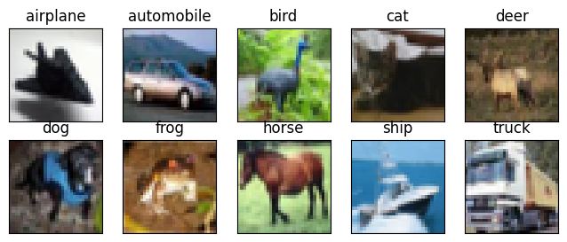

```python
# Display an example image for each class
class_names = ['airplane','automobile','bird','cat','deer','dog','frog','horse','ship','truck']

fig = plt.figure(figsize=(8,3))
num_classes = 10
for i in range(num_classes):
    ax = fig.add_subplot(2, 5, 1 + i, xticks=[], yticks=[])
    ax.set_title(class_names[i])
    img = next(img for img, label in train_cifar10 if label == i)
    plt.imshow(img.permute(1, 2, 0)) # torch.Size([32, 32, 3])
plt.show()
```

```python
# Examine the tensor of a truck image
print(img.shape)
print(img)
```

```
torch.Size([3, 32, 32])
tensor([[[0.6039, 0.4941, 0.4118,  ..., 0.3569, 0.3412, 0.3098],
         [0.5490, 0.5686, 0.4902,  ..., 0.3765, 0.3020, 0.2784],
         [0.5490, 0.5451, 0.4510,  ..., 0.3098, 0.2667, 0.2627],
         ...,
         [0.6863, 0.6118, 0.6039,  ..., 0.1647, 0.2392, 0.3647],
         [0.6471, 0.6118, 0.6235,  ..., 0.4039, 0.4824, 0.5137],
         [0.6392, 0.6196, 0.6392,  ..., 0.5608, 0.5608, 0.5608]],

        [[0.6941, 0.5373, 0.4078,  ..., 0.3725, 0.3529, 0.3176],
         [0.6275, 0.6000, 0.4902,  ..., 0.3882, 0.3137, 0.2863],
         [0.6078, 0.5725, 0.4510,  ..., 0.3216, 0.2745, 0.2706],
         ...,
         [0.6549, 0.6039, 0.6275,  ..., 0.1333, 0.2078, 0.3255],
         [0.6039, 0.5961, 0.6314,  ..., 0.3647, 0.4471, 0.4745],
         [0.5804, 0.5804, 0.6118,  ..., 0.5216, 0.5255, 0.5216]],

        [[0.7333, 0.5333, 0.3725,  ..., 0.2784, 0.2784, 0.2745],
         [0.6627, 0.6039, 0.4627,  ..., 0.3059, 0.2431, 0.2392],
         [0.6431, 0.5843, 0.4392,  ..., 0.2510, 0.2157, 0.2157],
         ...,
         [0.6510, 0.6275, 0.6667,  ..., 0.1412, 0.2235, 0.3569],
         [0.5020, 0.5098, 0.5569,  ..., 0.3765, 0.4706, 0.5137],
         [0.4706, 0.4784, 0.5216,  ..., 0.5451, 0.5569, 0.5647]]])
```

```python
# Examine the mean and std of images in the training data
imgs=torch.stack([img_t for img_t,label in train_cifar10],dim=3)
print(imgs.shape)
x7 = 32 * 32 * 50000
print(imgs.view(3,x7).mean(dim=1),imgs.view(3,x7).std(dim=1))
```

```
torch.Size([3, 32, 32, 50000])
tensor([0.4914, 0.4822, 0.4465]) tensor([0.2470, 0.2435, 0.2616])
```

**Q7.** What values can x7 take?

**Answer:** x7 takes the height, width and total number of images in the dataset, height:32, width:32 and number of images: 50000.

```python
# Define the image preprocessing pipeline to include normalization
cifar10_trans=transforms.Compose([
    transforms.ToTensor(),
    transforms.Normalize(mean=[0.4734],std=[0.2516])
])
```

```python
# Loading images and pass the images through our preprocessing pipeline
train_cifar10 = datasets.CIFAR10('/content/drive/MyDrive/IS675_data', train=True, download=True, transform=cifar10_transform)
test_cifar10 = datasets.CIFAR10('/content/drive/MyDrive/IS675_data', train=False, download=True, transform=cifar10_transform)
```

```
Files already downloaded and verified
Files already downloaded and verified
```

```python
# Define training and testing data loader, and set batch size to 256
train_loader = torch.utils.data.DataLoader(train_cifar10, batch_size=256, shuffle=True)
test_loader = torch.utils.data.DataLoader(test_cifar10, batch_size=256, shuffle=False)
```

```python
# Build a neural network on training data
class neural_network(nn.Module):
    def __init__(self,  in_size, hidden_size1,hidden_size2, out_size):
        super().__init__()
        self.network = nn.Sequential(
          nn.Linear(in_size, hidden_size1),
          nn.ReLU(),
          nn.Linear(hidden_size1, hidden_size2),
          nn.ReLU(),
          nn.Linear(hidden_size2, out_size))

    def forward(self, x):
        x_reshape=x.view(x.shape[0],-1)
        out = self.network(x_reshape)
        return out.squeeze()
```

```python
# Define training loop function
def training_loop(n_epochs, optimizer, model, loss_fn, train_loader):
    for epoch in range(0, n_epochs):
        # Training Phase
        model.train()
        loss_train = 0.0
        for inputs, labels in train_loader:

            outputs = model(inputs)
            loss = loss_fn(outputs, labels)

            optimizer.zero_grad()
            loss.backward()
            optimizer.step()
            loss_train += loss.item()

        if epoch == 0 or epoch == n_epochs-1 or epoch % 1 == 0:
            print('Epoch {}, Training loss {}'.format(epoch, loss_train / len(train_loader)))
```

**Q8.** Initialize the neural network with two hidden layers of size 256 and 64, choose adam optimizer and Cross Entropy loss, and train the model for 10 epochs.

```python
a1 = 3*32*32
a2 = 256
a3 = 64
a4 = 10
```

```python
# Q7. Model training
torch.manual_seed(0)
model = neural_network(a1, a2, a3, a4)
optimizer = optim.Adam(model.parameters())
loss_fn = nn.CrossEntropyLoss()

training_loop(n_epochs = 10, optimizer = optimizer, model = model, loss_fn = loss_fn, train_loader = train_loader)
```

[output not shown]

```python
# Define testing function
def test(model, train_loader, test_loader):

  # testing phase
  model.eval()
  predict_train = []
  predict_test = []
  labels_train = []
  labels_test = []

  with torch.no_grad():
      for inputs, labels in train_loader:
          outputs = model(inputs)
          index_, predicted = torch.max(outputs, dim=1)
          predict_train.append(predicted.tolist())
          labels_train.append(labels.tolist())

      for inputs, labels in test_loader:
          outputs = model(inputs)
          index_, predicted = torch.max(outputs, dim=1)
          predict_test.append(predicted.tolist())
          labels_test.append(labels.tolist())

  print("Confusion matrix on train:\n",  confusion_matrix(list(chain(*labels_train)), list(chain(*predict_train)), labels=[0,1,2,3,4,5,6,7,8,9]))
  print()
  print("Classification report on train:\n",  classification_report(list(chain(*labels_train)), list(chain(*predict_train)), labels=[0,1,2,3,4,5,6,7,8,9]))
  print()
  print("Confusion matrix on test:\n",  confusion_matrix(list(chain(*labels_test)), list(chain(*predict_test)), labels=[0,1,2,3,4,5,6,7,8,9]))
  print()
  print("Classification report on test:\n",  classification_report(list(chain(*labels_test)), list(chain(*predict_test)), labels=[0,1,2,3,4,5,6,7,8,9]))
```

```python
# Examine evaluation results
test(model, train_loader, test_loader)
```

[output not shown]

**Q9.** Describe the model's performance.

**Before submitting, make sure to keep only the evaluation results logs and close any other logs.**

```python
# Generate a html file
!jupyter nbconvert --to html "/content/drive/MyDrive/Colab Notebooks/IS675_lab08.ipynb"
```